# Homework 7

Shannon Hamilton

3/17/2018

```r
library(tidyverse)
library(broom)
```

## Exercise 1

*Load the train.csv dataset into R. How many observations and columns are there?*

```r
file_path <- '/Users/shamilto/Downloads/train.csv'
train <-read_csv(file_path,col_names=TRUE)
train <- as.tibble(train)
glimpse(train)
```

```
## Observations: 1,460
## Variables: 81
## $ Id            <int> 1, 2, 3, 4, 5, 6, 7, 8, 9, 10, 11, 12, 13, 14, 1...
## $ MSSubClass    <int> 60, 20, 60, 70, 60, 50, 20, 60, 50, 190, 20, 60,...
## $ MSZoning      <chr> "RL", "RL", "RL", "RL", "RL", "RL", "RL", "RL", ...
## $ LotFrontage   <int> 65, 80, 68, 60, 84, 85, 75, NA, 51, 50, 70, 85, ...
## $ LotArea       <int> 8450, 9600, 11250, 9550, 14260, 14115, 10084, 10...
## $ Street        <chr> "Pave", "Pave", "Pave", "Pave", "Pave", "Pave", ...
## $ Alley         <chr> NA, NA, NA, NA, NA, NA, NA, NA, NA, NA, NA, NA, ...
## $ LotShape      <chr> "Reg", "Reg", "IR1", "IR1", "IR1", "IR1", "Reg",...
## $ LandContour   <chr> "Lvl", "Lvl", "Lvl", "Lvl", "Lvl", "Lvl", "Lvl",...
## $ Utilities     <chr> "AllPub", "AllPub", "AllPub", "AllPub", "AllPub"...
## $ LotConfig     <chr> "Inside", "FR2", "Inside", "Corner", "FR2", "Ins...
## $ LandSlope     <chr> "Gtl", "Gtl", "Gtl", "Gtl", "Gtl", "Gtl", "Gtl",...
## $ Neighborhood  <chr> "CollgCr", "Veenker", "CollgCr", "Crawfor", "NoR...
```

[output cut: 68 more lines]

There are 1,460 observatons and 81 variables/columns.

## Exercise 2

```r
set.seed(29283)
# This data already has an Id column which we can make use of.
# Let's create our training set using sample_frac. Fill in the blank.

train_set <- train %>% sample_frac(0.7)

# let's create our testing set using the Id column. Fill in the blanks.

test_set <- train %>% filter(!(Id %in% train_set$Id))
glimpse(test_set)
```

```
## Observations: 438
## Variables: 81
## $ Id            <int> 1, 2, 3, 4, 14, 23, 27, 38, 40, 42, 45, 47, 48, ...
## $ MSSubClass    <int> 60, 20, 60, 70, 20, 20, 20, 20, 90, 20, 20, 50, ...
## $ MSZoning      <chr> "RL", "RL", "RL", "RL", "RL", "RL", "RL", "RL", ...
## $ LotFrontage   <int> 65, 80, 68, 60, 91, 75, 60, 74, 65, 115, 70, 48,...
## $ LotArea       <int> 8450, 9600, 11250, 9550, 10652, 9742, 7200, 8532...
## $ Street        <chr> "Pave", "Pave", "Pave", "Pave", "Pave", "Pave", ...
## $ Alley         <chr> NA, NA, NA, NA, NA, NA, NA, NA, NA, NA, NA, NA, ...
## $ LotShape      <chr> "Reg", "Reg", "IR1", "IR1", "IR1", "Reg", "Reg",...
## $ LandContour   <chr> "Lvl", "Lvl", "Lvl", "Lvl", "Lvl", "Lvl", "Lvl",...
## $ Utilities     <chr> "AllPub", "AllPub", "AllPub", "AllPub", "AllPub"...
## $ LotConfig     <chr> "Inside", "FR2", "Inside", "Corner", "Inside", "...
## $ LandSlope     <chr> "Gtl", "Gtl", "Gtl", "Gtl", "Gtl", "Gtl", "Gtl",...
## $ Neighborhood  <chr> "CollgCr", "Veenker", "CollgCr", "Crawfor", "Col...
```

[output cut: 68 more lines]

## Exercise 3

```r
mean(train_set$SalePrice)
```

```
## [1] 182176
```

```r
mod_0 <- lm(SalePrice ~ 1, data = train_set)

tidy(mod_0)
```

```
##          term estimate std.error statistic p.value
## 1 (Intercept)   182176  2492.072  73.10222       0
```

```r
# Check the R-squared
glance(mod_0)
```

```
##   r.squared adj.r.squared    sigma statistic p.value df    logLik      AIC
## 1         0             0 79668.37        NA      NA  1 -12983.57 25971.13
##        BIC     deviance df.residual
## 1 25980.99 6.480338e+12        1021
```

## Exercise 4

*1. What kind of relationship will these features have with our target?*

I would expect that the square footage of the home and the quality to have positive relationships to the sale price. I would expect certain areas to be correlated with higher sale prices and certain areas to be correlated with lower sale prices.

*2. Can the relationship be estimated linearly?*

I think it is reasonable to estimate the relationship linearly.

*3. Are these good features, given the problem we are trying to solve?*

Yes, I would imagine that the amount of living area, quality of the house and location to be strong predictors of home prices.

*After fitting the model, output the coefficients and the R-squared using the broom package:*

```r
mod_1 <- lm(SalePrice ~ (GrLivArea+OverallQual+Neighborhood), data = train_set)

tidy(mod_1)
```

```
##                   term     estimate    std.error  statistic      p.value
## 1          (Intercept) -45017.87483 12933.341808 -3.4807612 5.216927e-04
## 2            GrLivArea     62.77735     3.006033 20.8837885 1.337222e-80
## 3          OverallQual  21692.23178  1353.714104 16.0242342 1.389020e-51
## 4  NeighborhoodBlueste -38288.88063 36531.907177 -1.0480942 2.948497e-01
## 5   NeighborhoodBrDale -43314.05372 14524.693991 -2.9820975 2.932566e-03
## 6  NeighborhoodBrkSide -14064.37052 11318.850018 -1.2425618 2.143221e-01
## 7  NeighborhoodClearCr  27839.00662 13561.346871  2.0528202 4.035110e-02
## 8  NeighborhoodCollgCr   4297.67432 10372.304467  0.4143413 6.787135e-01
## 9  NeighborhoodCrawfor   7423.05573 11371.511784  0.6527765 5.140512e-01
## 10 NeighborhoodEdwards -15284.11495 10994.287187 -1.3901870 1.647830e-01
## 11 NeighborhoodGilbert  -8357.55930 10894.173472 -0.7671586 4.431692e-01
## 12  NeighborhoodIDOTRR -32689.43085 12603.712743 -2.5936350 9.636216e-03
## 13 NeighborhoodMeadowV -14446.06504 14190.148622 -1.0180348 3.089089e-01
## 14 NeighborhoodMitchel   1922.31487 11788.608170  0.1630655 8.705000e-01
## 15   NeighborhoodNAmes  -7719.67883 10375.956174 -0.7439969 4.570540e-01
## 16 NeighborhoodNoRidge  47685.16790 12567.432633  3.7943444 1.569690e-04
## 17 NeighborhoodNPkVill -20240.71145 16548.664867 -1.2231024 2.215806e-01
## 18 NeighborhoodNridgHt  63872.80848 10880.456671  5.8704161 5.917964e-09
## 19  NeighborhoodNWAmes -12279.33299 11047.502893 -1.1115030 2.666204e-01
## 20 NeighborhoodOldTown -36107.07577 10849.170903 -3.3280954 9.064637e-04
## 21  NeighborhoodSawyer  -4121.92502 11252.369778 -0.3663162 7.142070e-01
## 22 NeighborhoodSawyerW  -5391.97074 11230.758221 -0.4801075 6.312565e-01
## 23 NeighborhoodSomerst  18700.96725 10772.212794  1.7360377 8.286672e-02
## 24 NeighborhoodStoneBr  65712.45881 12745.312907  5.1558137 3.045915e-07
## 25   NeighborhoodSWISU -45451.86707 13564.792586 -3.3507233 8.363074e-04
## 26  NeighborhoodTimber  27925.08619 11985.325857  2.3299397 2.000859e-02
## 27 NeighborhoodVeenker  54913.12768 16521.075497  3.3238228 9.203087e-04
```

```r
glance(mod_1)
```

```
##   r.squared adj.r.squared   sigma statistic p.value df    logLik      AIC
## 1 0.8099927     0.8050277 35178.1  163.1401       0 27 -12134.95 24325.91
##        BIC     deviance df.residual
## 1 24463.93 1.231311e+12         995
```

*1. How would you interpret the coefficients on GrLivArea and OverallQual?*

For every additional square foot of above ground living, the price of the home increases by $62 on average, holding quality and neighborhood constant.

For every one point increase in quality, the price of the home increases by $21,692 on average, holding size and neighborhood constant.

*2. How would you interpret the coefficient on NeighborhoodBrkSide?*

Compared to Bloomington Heights, a home being located in Brookside on average decreases the value of the home by $14,064, holding size and quality constant.

*3. Are the features significant?*

*4. Are the features practically significant?*

I would say all the features are practically significant given their size impact. Although the per squarefoot increase looks relatively smaller of an impact compared to the other features, one squarefoot is a small measurement compared to the overall size of a house making this a practically significant feautre.

*5. Is the model a good fit (to the training set)?*

With an R-squared and adjusted R-squared of ~80%, this model is a good fit to the training set.

## Exercise 5

RMSE should be considered wihtin the context of the units of the target feature. 41915 impact on the price of a house I would consider substantial. Therefore, I would say this model didn’t performa as well on the test data as I would have hoped;.

```r
test_predictions <- predict(mod_1, newdata = test_set)
(rmse <- sqrt(mean((test_set$SalePrice - test_predictions)^2)))
```

```
## [1] 41915.27
```

## Exercise 7

```r
sim1a <- tibble(
x = rep(1:10, each = 3),
y = x * 1.5 + 6 + rt(length(x), df = 2)
)

mod_2 <- lm(sim1a$y ~ sim1a$x, data = train_set)

tidy(mod_2)
```

```
##          term estimate std.error statistic      p.value
## 1 (Intercept) 6.694060 0.8711790  7.683909 2.270460e-08
## 2     sim1a$x 1.456668 0.1404032 10.374889 4.244805e-11
```

```r
glance(mod_2)
```

```
##   r.squared adj.r.squared    sigma statistic      p.value df    logLik
## 1 0.7935687     0.7861961 2.208842  107.6383 4.244805e-11  2 -65.30731
##        AIC      BIC deviance df.residual
## 1 136.6146 140.8182 136.6115          28
```

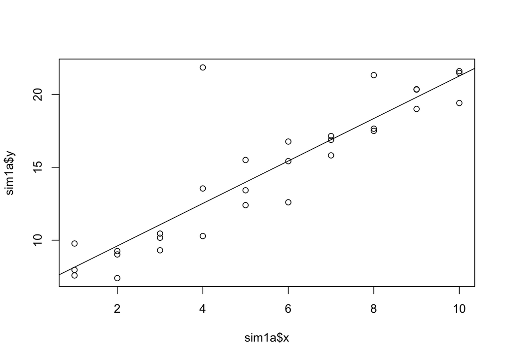

```r
plot(sim1a$y ~ sim1a$x, data = train_set)
abline(mod_2)
```

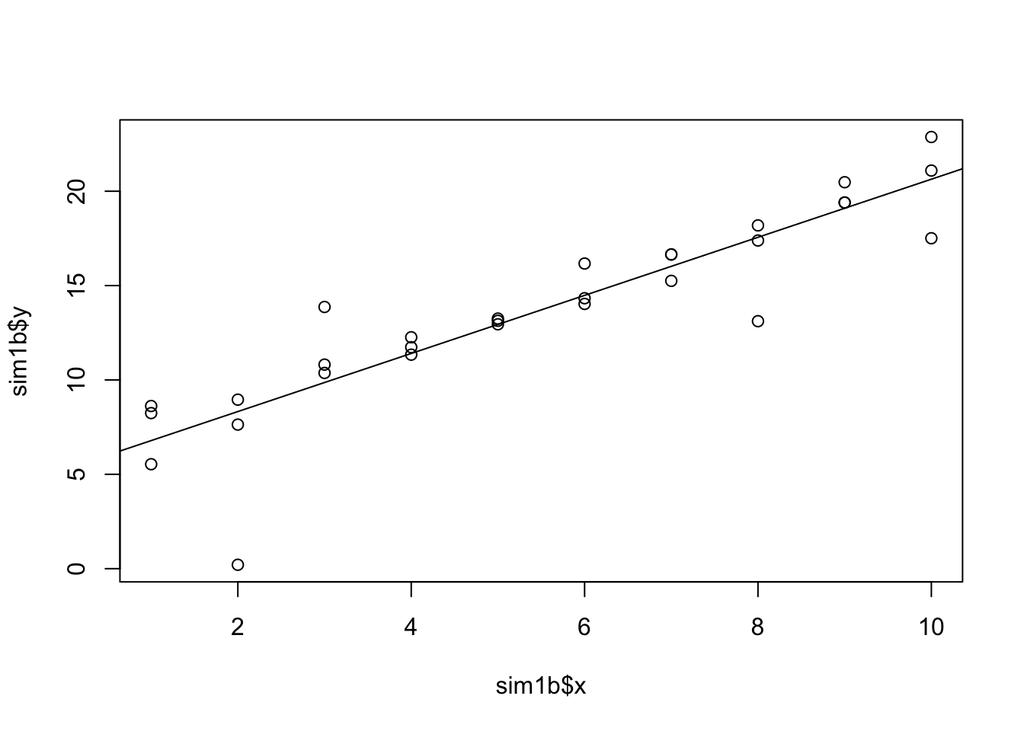

```r
#another run
sim1b <- tibble(
x = rep(1:10, each = 3),
y = x * 1.5 + 6 + rt(length(x), df = 2)
)

mod_3 <- lm(sim1b$y ~ sim1b$x, data = train_set)


plot(sim1b$y ~ sim1b$x, data = train_set)
abline(mod_3)
```

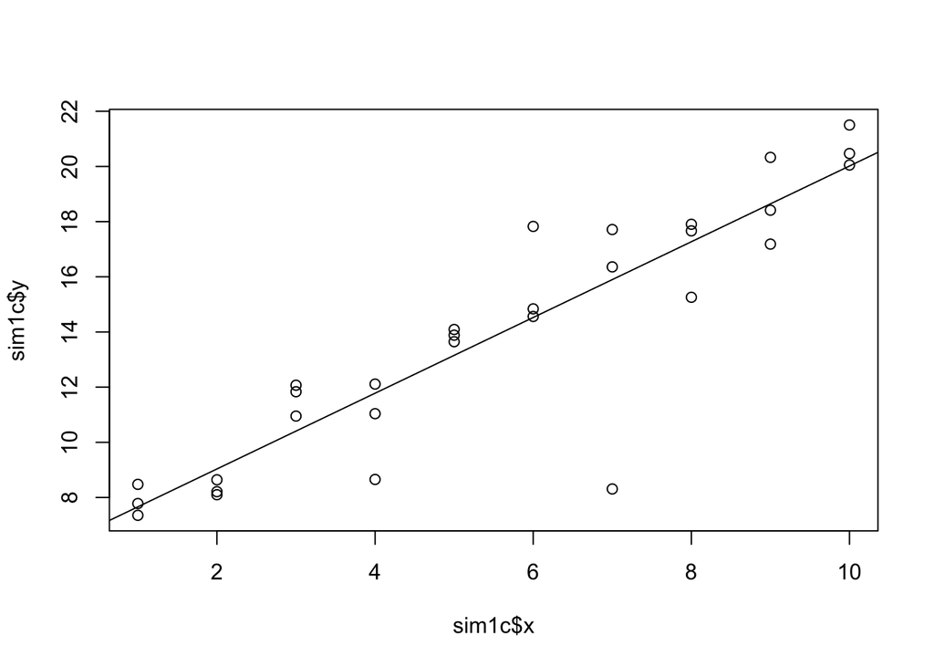

```r
#another run
sim1c <- tibble(
x = rep(1:10, each = 3),
y = x * 1.5 + 6 + rt(length(x), df = 2)
)

mod_4 <- lm(sim1c$y ~ sim1c$x, data = train_set)


plot(sim1c$y ~ sim1c$x, data = train_set)
abline(mod_4)
```

*What do you notice about the model?*